# PEC 1 - Regresión, modelos y métodos

Candela Sánchez

2025-11-23

Las olas de calor son fenómenos meteorológicos extremos caracterizados por un aumento anómalo y persistente de las temperaturas. La AEMET presentó un informe [1] con datos e información precisa sobre olas de calor registradas en España entre 1975 y 2024. Para cada ola se dispone de:

- **a**: año del evento inicio: día de inicio
- **fin**: día de finalización duracion: duración de la ola de calor (en días)
- **anomalia**: diferencia de temperatura media respecto al valor normal (oC)
- **temp_max**: temperatura máxima registrada durante la ola (oC)
- **num_prov**: número de provincias afectadas

El objetivo del análisis es estudiar qué factores explican la extensión geográfica (número de provincias afectadas) de las olas de calor.

## Ejercicio 1 (50pt.)

### a. **Exploración inicial**

```r
# Primero vamos a cargar los datos que necesitamos
load("C:/Users/Candix/OneDrive - Questindustries/Escritorio/Master Bioinformática/2 cuatri/Regresion, modelos y metodos/odc_aemet_1975_2024.RData")

# Observamos que se ha cargado y verficamos su nombre
ls()
```

```
## [1] "tbl"
```

```r
# Una vez que sabemos el nombre de los datos miramos su estructura
str(tbl)
```

```
## 'data.frame':    75 obs. of  7 variables:
##  $ a       : int  2024 2024 2024 2023 2023 2023 2023 2022 2022 2022 ...
##  $ inicio  : Date, format: "2024-07-18" "2024-07-23" ...
##  $ fin     : Date, format: "2024-07-20" "2024-08-01" ...
##  $ duracion: int  3 10 9 4 4 8 9 7 18 16 ...
##  $ anomalia: num  2.9 3.2 2.6 3.2 3.5 3.3 4 3.2 4.5 3.5 ...
##  $ temp_max: num  37.6 36.6 37.9 39 38.8 38.6 38.7 37.7 38.1 36.6 ...
##  $ num_prov: int  14 33 35 15 21 26 39 39 44 33 ...
```

#### - Muestra un resumen estadístico de las variables cuantitativas

```r
# Mostramos un resumen estadistico de las variables cuantitativas
summary(tbl[,c("duracion", "anomalia", "temp_max", "num_prov")])
```

```
##     duracion         anomalia        temp_max        num_prov
##  Min.   : 3.000   Min.   :1.300   Min.   :34.10   Min.   : 9.00
##  1st Qu.: 3.000   1st Qu.:1.950   1st Qu.:36.95   1st Qu.:14.00
##  Median : 4.000   Median :2.600   Median :37.70   Median :20.00
##  Mean   : 5.627   Mean   :2.589   Mean   :37.73   Mean   :21.89
##  3rd Qu.: 6.000   3rd Qu.:3.200   3rd Qu.:38.70   3rd Qu.:29.00
##  Max.   :26.000   Max.   :4.500   Max.   :41.10   Max.   :44.00
```

#### - Dibuja la **figura 3** del informa de la AEMET. Para ello habrá que agrupar los datos de cada año y rellener los años que faltan con valores 0 para las variables consideradas en la figura 3.

```r
# Cargamos los paquetes necesarios
library(dplyr)
library(tidyr)
```

```r
# Agrupamos los datos de cada año y rellenamos con 0 los años que faltan valores
# Creamos una variable con todos los años
todos_años<- data.frame(a=1975:2024)

# Agrupamos los datos
datos_fig3 <- tbl %>%
  group_by(a) %>% # Agrupamos todos los eventos que sean del mismo año
  summarise(
    numero_episodios=n(), # Contamos cuantos episodios hun con n()
    numero_dias=sum(duracion), # Sumamos todos los dias con olas de calor
    duracion_max=max(duracion), # Duracion max de la ola de calor mas larga
) %>%
# Completamos con 0 los años que faltan
right_join(todos_años, by="a") %>% # Unimos todos los años con los que hemos calculado
replace_na(list(numero_episodios=0, numero_dias=0, duracion_max=0)) %>% # Ponemos 0 en los años que no tenian datos
arrange(a) # Ordenamos en orden cronológicos

# Mostramos los datos de la Figura 3 para comprobarlos
head(datos_fig3)
```

```
## # A tibble: 6 × 4
##       a numero_episodios numero_dias duracion_max
##   <int>            <int>       <int>        <int>
## 1  1975                1           4            4
## 2  1976                1           3            3
## 3  1977                0           0            0
## 4  1978                1           4            4
## 5  1979                1           3            3
## 6  1980                0           0            0
```

[figure not shown]

```r
# Dibujamos la figura 3
library(ggplot2) #Cargamos el paquete necesario para hacer el grafico

# Convertimos los datos a formato largo porque ggplot no puede dibujar directamenten varias variables en columnas
fig3_datos_largos <- datos_fig3 %>%
  pivot_longer(cols = c(numero_episodios, numero_dias, duracion_max),
               names_to = "variable",
               values_to = "valor")

ggplot(fig3_datos_largos, aes(x = a, y = valor, fill = variable)) +
  geom_bar(stat = "identity", position = "dodge") +
  labs(title = "Episodios de ola de calor, números de días con ola de calor durante
el verano y duración de la ola de calor más larga de cada verano,
desde 1975",
       x = "Año",
       y = "Valor") + #Añadimos etiquetas a los ejes
# Ponemos colores a cada variable
  scale_fill_manual(values = c("numero_episodios" = "red",
                               "numero_dias" = "pink",
                               "duracion_max" = "blue"),
                    name = "Variable",
                    labels = c("Episodios", "Numero de días", "Duración máxima")) +
  theme_minimal()
```

#### - Representa mediante gráficos de dispersión la relación entre **num_prov** y las posibles variables predictoras **(duracion, anomalia, temp_max)** de tbl. Comenta si parece existir una relación lineal.

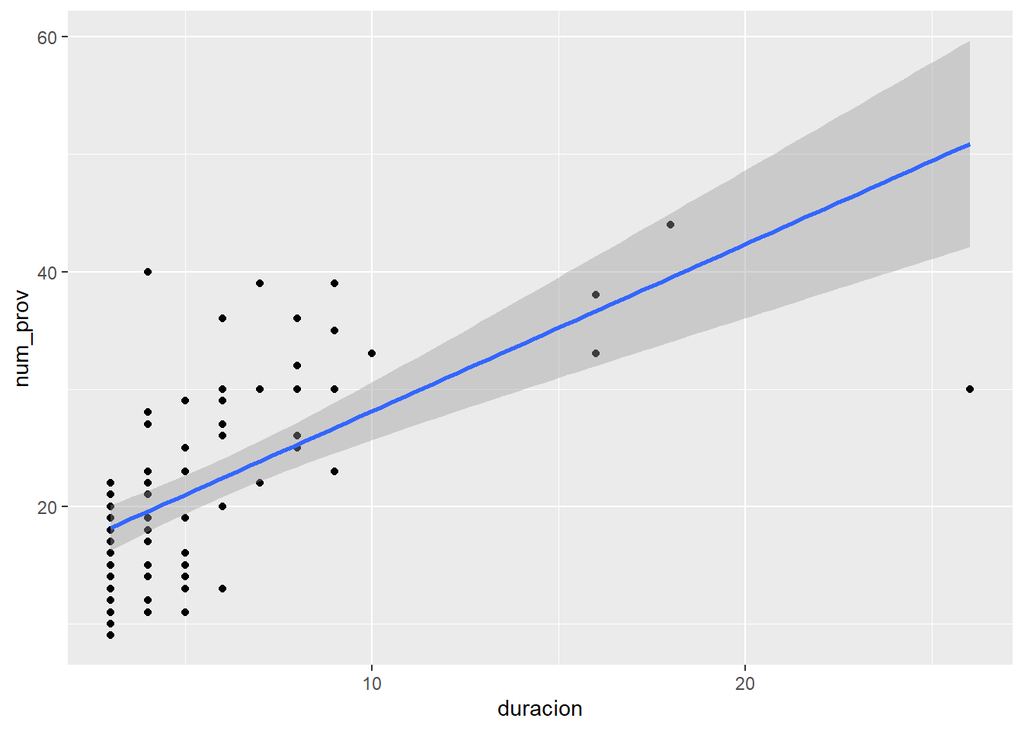

```r
# Representamos la relacion entre el numero de provincias y la duracion
ggplot(tbl, aes(x = duracion, y = num_prov)) + geom_point() + geom_smooth(method="lm")
```

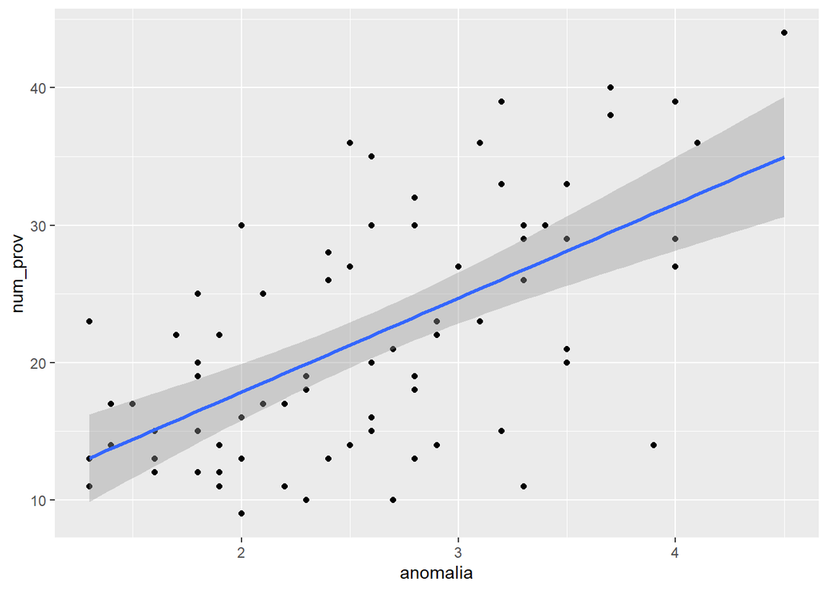

```r
# Representamos la relacion entre el numero de provincias y la anomalia
ggplot(tbl, aes(x = anomalia, y = num_prov)) + geom_point() + geom_smooth(method="lm")
```

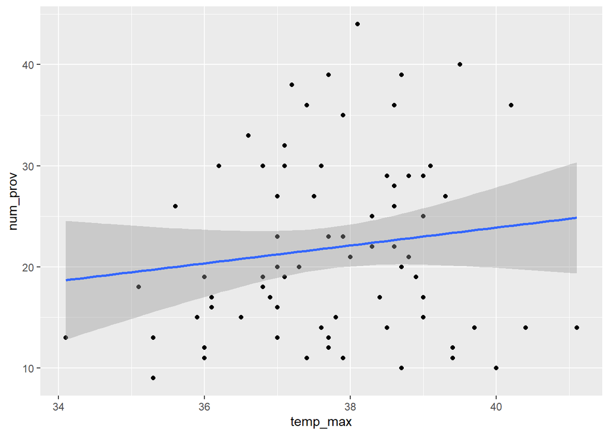

```r
# Representamos la relacion entre el numero de provincias y la temp_max
ggplot(tbl, aes(x = temp_max, y = num_prov)) + geom_point() + geom_smooth(method="lm")
```

Las gráficas muestran la relación entre el número de provincias y las variables duración, anomalía y temperatura máxima. Podemos observar que las variables duración y anomalía tienen una relación positiva con el número de provincias afectadas, ya que a mayor duración o anomalía, mayor es el número de provincias afectadas. Aunque en la gráfica de anomalía se aprecia mayor dispersión, lo que indica que el efecto es menos consistente. Por otro lado, en el tercer gráfico vemos que la relación entre la temperatura máxima y el número de provincias no es clara, debido a que los puntos están muy dispersos y la línea es casi plana.

### b. Regresión lineal múltiple

#### - Ajusta un modelo de regresión lineal múltiple con estas variables cuantitativas.

```r
# Ajustamos un modelo de regresion lineal multiple
modelo_rlm <- lm(num_prov~duracion+anomalia+temp_max, data=tbl)
```

#### - Muestra el resumen del modelo.

```r
# Resumen del modelo
summary(modelo_rlm)
```

```
##
## Call:
## lm(formula = num_prov ~ duracion + anomalia + temp_max, data = tbl)
##
## Residuals:
##      Min       1Q   Median       3Q      Max
## -15.5642  -3.5113  -0.5748   4.4165  14.4401
##
## Coefficients:
##             Estimate Std. Error t value Pr(>|t|)
## (Intercept)  -7.0876    21.4790  -0.330  0.74239
## duracion      0.9955     0.2296   4.336  4.7e-05 ***
## anomalia      4.2364     1.1723   3.614  0.00056 ***
## temp_max      0.3289     0.5847   0.562  0.57559
## ---
## Signif. codes:  0 '***' 0.001 '**' 0.01 '*' 0.05 '.' 0.1 ' ' 1
##
## Residual standard error: 6.402 on 71 degrees of freedom
## Multiple R-squared:  0.4972, Adjusted R-squared:  0.476
## F-statistic:  23.4 on 3 and 71 DF,  p-value: 1.218e-10
```

#### - Interpreta el significado y el signo de los coeficientes estimados.

Se puede observar en los resultados que el coeficiente de duración es positivo (0.9955), lo que indica que por cada día adicional de ola de calor, el número de provincias afectadas aumenta aproximadamente en 1. El coeficiente de la anomalía también es positivo (4.2364), lo que indica que por cada grado extra se ven afectadas aproximadamente 4 provincias. Por último, el coeficiente de la temperatura máxima es positivo, pero muy pequeño (0.3289), lo que indica que por cada grado extra en la ola de calor el número de provincias afectadas aumenta unicamente en un 0.33, pero este resultado no es estadísticamente significativo.

#### - Indica qué variables son significativas a nivel individual (α = 0.05).

Los resultados indican que las variables duración y anomalía son estadísticamente significativas con un p-valor<0.001. En cuanto a la temperatura máxima el p-valor es mayor que 0.05 por lo que no es estadísticamente significativo.

#### - Interpreta el coeficiente de determinación R2 evaluando el valor obtenido.

El modelo tiene un R²=0.4972, lo que indica que es capaz de explicar aproximadamente el 50% de la variabilidad observada en el número de provincias afectadas por las olas de calor.

### c. Añadimos la variable “mes”

##### Dado que el R2 ha resultado ser un poco bajo, es posible que nos hayamos dejado variables predictoras de las que disponemos. Proponemos introducir el mes en el que se produce el evento como variable predictora cualitativa. Para ello crearemos un factor cuyos niveles sean junio, julio, agosto y septiembre. Si algún evento toma días de dos meses diferentes se tomará como mes al que le correspondan más días del evento.

##### Cada ola de calor se caracteriza por una fecha de inicio (inicio) y una fecha de fin (fin) y como queremos incluir en el modelo el mes en el que ocurre principalmente el evento, de modo que podamos analizar si el número de provincias afectadas depende también del mes del año, calcularemos el punto medio de cada evento y extraeremos el mes correspondiente. El nuevo factor mes tendrá cuatro niveles: junio, julio, agosto y septiembre.

##### ¿En cuánto ha mejorado el ajuste? Interpretar el modelo que se ha obtenido.

##### Nota: Para facilitar el tratamiento de fechas, se recomienda el uso del paquete lubridate que dispone de la función month() que identifica el número del mes.

```r
# Cargamos los paquetes necesarios
library(lubridate)
library(dplyr)
library(tidyr)

# Creamos la variable mes a partir del pundo medio del evento
tbl$fecha_medio<- tbl$inicio+(tbl$fin-tbl$inicio)/2 # Calculamos el punto medio
# del evento
tbl$mes <- factor(month(tbl$fecha_medio, label=TRUE, abbr = FALSE), # Usamos
                  # month() para extraer el mes del punto medio
                  levels=c("junio", "julio", "agosto", "septiembre"))

# Comprobamos si lo hemos hecho bien
head(tbl)
```

```
##      a     inicio        fin duracion anomalia temp_max num_prov fecha_medio
## 1 2024 2024-07-18 2024-07-20        3      2.9     37.6       14  2024-07-19
## 2 2024 2024-07-23 2024-08-01       10      3.2     36.6       33  2024-07-27
## 3 2024 2024-08-04 2024-08-12        9      2.6     37.9       35  2024-08-08
## 4 2023 2023-07-09 2023-07-12        4      3.2     39.0       15  2023-07-11
## 5 2023 2023-07-17 2023-07-20        4      3.5     38.8       21  2023-07-19
## 6 2023 2023-08-06 2023-08-13        8      3.3     38.6       26  2023-08-10
##      mes
## 1  julio
## 2  julio
## 3 agosto
## 4  julio
## 5  julio
## 6 agosto
```

```r
# Ajustamos el modelo con la nueva variable
modelo_mes<-lm(num_prov~duracion+anomalia+temp_max+mes, data=tbl)

# Resumen del modelo
summary(modelo_mes)
```

```
##
## Call:
## lm(formula = num_prov ~ duracion + anomalia + temp_max + mes,
##     data = tbl)
##
## Residuals:
##      Min       1Q   Median       3Q      Max
## -14.2383  -3.6569  -0.5269   4.3155  15.8369
##
## Coefficients:
##             Estimate Std. Error t value Pr(>|t|)
## (Intercept) -12.4579    21.7783  -0.572 0.569186
## duracion      1.0119     0.2306   4.389 4.07e-05 ***
## anomalia      4.1543     1.1890   3.494 0.000842 ***
## temp_max      0.4886     0.5974   0.818 0.416291
## mes.L        -1.2223     2.6507  -0.461 0.646181
## mes.Q         1.7072     2.0977   0.814 0.418562
## mes.C        -2.2795     1.3823  -1.649 0.103732
## ---
## Signif. codes:  0 '***' 0.001 '**' 0.01 '*' 0.05 '.' 0.1 ' ' 1
##
## Residual standard error: 6.347 on 68 degrees of freedom
## Multiple R-squared:  0.5267, Adjusted R-squared:  0.4849
## F-statistic: 12.61 on 6 and 68 DF,  p-value: 1.658e-09
```

Se puede observar que al añadir la variable “mes”, el R² aumenta de 0.4972 a 0.5267, indicando que ha habido una pequeña mejora en el modelo al añadir la variable. También se observa que tanto la duración como la anomalía siguen siendo estadísticamente significativas y mantienen un efecto positivo sobre el número de provincias afectadas. Sin embargo, ni la temperatura máxima ni el mes son significativos, por lo que ninguno muestra un impacto importante a nivel individual.

En conclusión, el ajuste en el modelo provoca una ligera mejora, pero no afecta significativamente de forma individual, aunque sí causa cierta variabilidad residual en los datos.

### d. Variable dicotómica “julio”

#### Se pide agrupar los meses que no sean julio y ajustar un modelo con la variable dicotómica entre julio y otros meses e interpretar los resultados

```r
# Creamos la variable dicotomica
tbl$julio<- ifelse(tbl$mes == "julio", "julio", "otros") # Usamos ifelse()
# para convertir el factor mes en una variable binaria, es decir, una variable
# que cuenta con julio y otros
tbl$julio <- factor(tbl$julio,levels=c("otros","julio")) # Convertimos a factor
# para el modelo

# Comprobamos si lo hemos hecho bien
head(tbl)
```

```
##      a     inicio        fin duracion anomalia temp_max num_prov fecha_medio
## 1 2024 2024-07-18 2024-07-20        3      2.9     37.6       14  2024-07-19
## 2 2024 2024-07-23 2024-08-01       10      3.2     36.6       33  2024-07-27
## 3 2024 2024-08-04 2024-08-12        9      2.6     37.9       35  2024-08-08
## 4 2023 2023-07-09 2023-07-12        4      3.2     39.0       15  2023-07-11
## 5 2023 2023-07-17 2023-07-20        4      3.5     38.8       21  2023-07-19
## 6 2023 2023-08-06 2023-08-13        8      3.3     38.6       26  2023-08-10
##      mes julio
## 1  julio julio
## 2  julio julio
## 3 agosto otros
## 4  julio julio
## 5  julio julio
## 6 agosto otros
```

```r
# Ajustamos el modelo con la nueva variable
modelo_julio<-lm(num_prov ~ duracion + anomalia + temp_max + julio, data = tbl)

# Resumen del modelo
summary(modelo_julio)
```

```
##
## Call:
## lm(formula = num_prov ~ duracion + anomalia + temp_max + julio,
##     data = tbl)
##
## Residuals:
##      Min       1Q   Median       3Q      Max
## -14.4313  -4.0219  -0.7216   4.1864  15.8545
##
## Coefficients:
##             Estimate Std. Error t value Pr(>|t|)
## (Intercept) -13.5220    21.3595  -0.633 0.528753
## duracion      1.0292     0.2261   4.552 2.18e-05 ***
## anomalia      3.9924     1.1582   3.447 0.000963 ***
## temp_max      0.5443     0.5852   0.930 0.355516
## juliojulio   -2.8451     1.4922  -1.907 0.060680 .
## ---
## Signif. codes:  0 '***' 0.001 '**' 0.01 '*' 0.05 '.' 0.1 ' ' 1
##
## Residual standard error: 6.286 on 70 degrees of freedom
## Multiple R-squared:  0.522,  Adjusted R-squared:  0.4947
## F-statistic: 19.11 on 4 and 70 DF,  p-value: 1.159e-10
```

Se puede observar que con este ajuste, el R² aumenta de 0.4972 a 0.522, indicando que ha habido una pequeña mejora en el modelo. Se sigue observando que las variables “duración” y “anomlía” siguen siendo estadísticamente positivas y con un efecto positivo. La temperatura máxima sigue siendo no significativas, y el efecto de julio es negativo y algo significativo debido a que su p-valor es aproximadamente 0.06. Esto puede indicar que en julio podría haber menos provincias afectadas que en los otros meses.

En conclusión, el ajuste en el modelo provoca una ligera mejora, pero no afecta significativamente de forma individual, aunque sí causa cierta variabilidad residual en los datos.

### e. Modelo con interacción

#### Ajustar un modelo más general que contemple que el efecto lineal de las diferentes variables cuantitativas sea diferente según sea el mes de julio u otros meses e interpretar los resultados.

```r
# Ajustamos a un modelo mas general
modelo_general <- lm(num_prov ~ duracion*julio + anomalia*julio + temp_max*julio, data = tbl)

# Resumen del modelo
summary(modelo_general)
```

```
##
## Call:
## lm(formula = num_prov ~ duracion * julio + anomalia * julio +
##     temp_max * julio, data = tbl)
##
## Residuals:
##      Min       1Q   Median       3Q      Max
## -14.9201  -4.3482  -0.7513   4.1473  14.9526
##
## Coefficients:
##                     Estimate Std. Error t value Pr(>|t|)
## (Intercept)         -66.5196    27.2826  -2.438 0.017420 *
## duracion              1.3571     0.3857   3.519 0.000784 ***
## juliojulio          111.9057    41.4380   2.701 0.008757 **
## anomalia              4.2740     1.5373   2.780 0.007048 **
## temp_max              1.8879     0.7420   2.544 0.013263 *
## duracion:juliojulio  -0.4753     0.4666  -1.019 0.312044
## juliojulio:anomalia  -0.6878     2.2465  -0.306 0.760433
## juliojulio:temp_max  -2.9198     1.1289  -2.586 0.011874 *
## ---
## Signif. codes:  0 '***' 0.001 '**' 0.01 '*' 0.05 '.' 0.1 ' ' 1
##
## Residual standard error: 5.986 on 67 degrees of freedom
## Multiple R-squared:  0.5851, Adjusted R-squared:  0.5418
## F-statistic:  13.5 on 7 and 67 DF,  p-value: 9.696e-11
```

Se puede observar que el R² aumenta hasta 0.5851, siendo bastante mejor que en los otros modelos. En cuento a los coeficinetes, se observa que solo hay diferencias estadisticamentes significativas en las interacciones entre la temperatura maxima y julio siendo el p-valor=0.011874, mientras que en las interacciones del mes de julio con la duración y la anomalía no hay diferencias estadísticamente significativas. Por lo tanto, el efecto de la temperatura máxima varía entre julio y el resto de los meses, mientras que el efecto de la duración y la anomalía parece ser igual a lo largo de todos los meses.

#### Por último estimar un modelo reducido que, además de las variables numéricas, solo incluya la interacción entre temperatura máxima y julio. Especificar la ecuación del modelo y comparar con el test estadístico adecuado este modelo con el anterior (todas las interacciones) y comprobar si nos podemos quedar con el modelo reducido.

```r
# Ajustamos a un modelo mas reducido
modelo_reducido<- lm(num_prov ~ duracion + anomalia + temp_max * julio, data = tbl)

# Resumen del modelo
summary(modelo_reducido)
```

```
##
## Call:
## lm(formula = num_prov ~ duracion + anomalia + temp_max * julio,
##     data = tbl)
##
## Residuals:
##      Min       1Q   Median       3Q      Max
## -15.0674  -3.8424  -0.4962   4.1743  14.8888
##
## Coefficients:
##                     Estimate Std. Error t value Pr(>|t|)
## (Intercept)         -63.2410    26.8190  -2.358 0.021210 *
## duracion              1.0056     0.2156   4.664 1.47e-05 ***
## anomalia              4.2124     1.1063   3.808 0.000301 ***
## temp_max              1.8570     0.7236   2.566 0.012450 *
## juliojulio          110.4931    39.8404   2.773 0.007129 **
## temp_max:juliojulio  -2.9988     1.0535  -2.847 0.005815 **
## ---
## Signif. codes:  0 '***' 0.001 '**' 0.01 '*' 0.05 '.' 0.1 ' ' 1
##
## Residual standard error: 5.99 on 69 degrees of freedom
## Multiple R-squared:  0.5723, Adjusted R-squared:  0.5413
## F-statistic: 18.46 on 5 and 69 DF,  p-value: 1.356e-11
```

```r
# Comparamos los modelos con el test de ANOVA
anova(modelo_general, modelo_reducido)
```

```
## Analysis of Variance Table
##
## Model 1: num_prov ~ duracion * julio + anomalia * julio + temp_max * julio
## Model 2: num_prov ~ duracion + anomalia + temp_max * julio
##   Res.Df    RSS Df Sum of Sq      F Pr(>F)
## 1     67 2400.9
## 2     69 2475.4 -2   -74.524 1.0398 0.3591
```

**Ecuación del modelo:**

num_prov=β0+β1⋅duracion+β2⋅anomalia+β3⋅temp_max+β34⋅julio+β5⋅(temp_max×julio)

Para comprobar si nos podemos quedar con este modelo, se ha comparado el modelo completo con el reducido mediante un test ANOVA.

Las hipótesis del test son:

- Hipótesis nula es la que las interacciones del mes de julio con la duración y la anomalía no aportan información.
- Hipótesis alternativa es la que al menos una de las interacciones aporta información.

En cuanto al criterio de decisión:

- Si el p-valor es mayor que 0.05, no se rechaza la hipótesis nula por lo que el modelo reducido sería suficiente
- Si es menor a 0.05, se rechaza la hipótesis nula por lo que las interacciones si aportan información significativa por lo que nos tenemos quedar con el modelo completo.

En este caso, el p-valor=0.3591, por lo que no se rechaza la hipótesis nula y nos podemos quedar con el modelo reducido.

### f. Predicción

#### Considerar el modelo reducido del apartado anterior y mejor si proporcionamos el intervalo de confianza de la predicción.

```r
# Nuevos valores para la prediccion
ola_calor <- data.frame(duracion=5, anomalia=5, temp_max=38, julio= factor("otros", levels=c("otros","julio"))) # Agosto se encuentra en la variable "Otros"

# Calculamos la prediccion con un intervalo de confianza del 95%
predict(modelo_reducido, newdata = ola_calor, interval ="confidence", level=0.95 )
```

```
##        fit     lwr      upr
## 1 33.41417 27.8042 39.02415
```

### g. Gráfico con la temperatura máxima y el mes de julio

#### Representar gráficamente el número de provincias afectadas en función de la temperatura máxima, el factor “mes de julio” y su interacción.

#### Explicar el significado del coeficiente asociado a la interacción e identificar el valor de las pendientes de las dos rectas. ¿Cómo es el comportamiento del mes de julio respecto a los demás meses en el número de provincias afectadas?

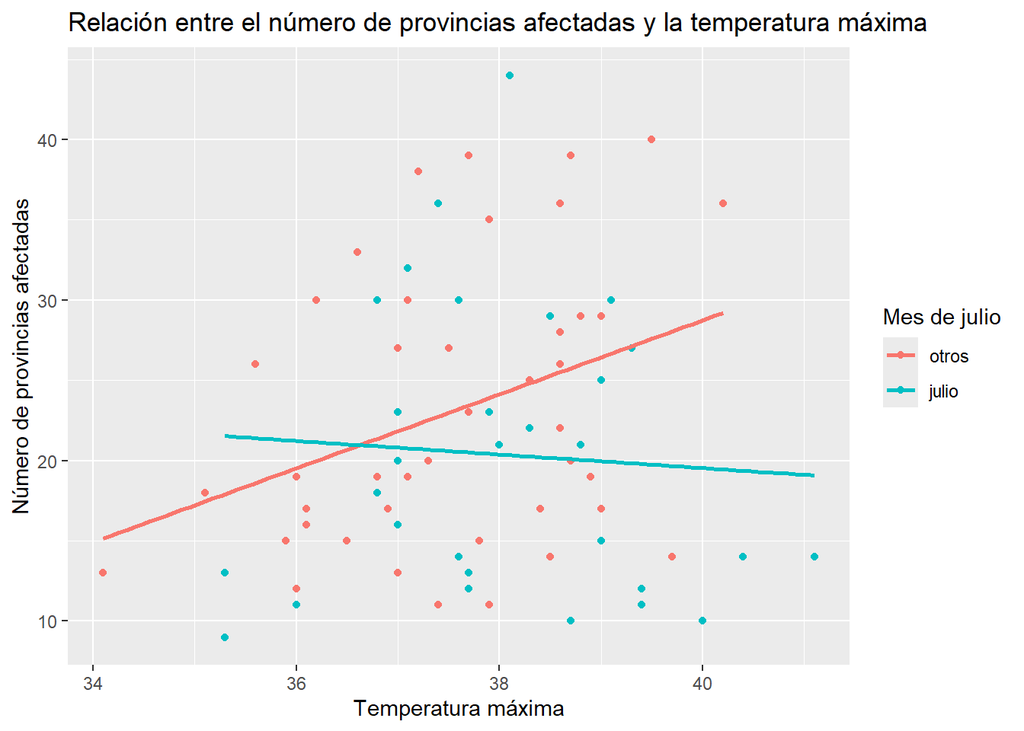

```r
# Dibujamos el grafico de el numero de provincias afectas en funcion de la temperatura maxima
ggplot(tbl, aes(x=temp_max, y=num_prov, color=julio))+
  geom_point()+
  geom_smooth(method="lm", se=FALSE)+
  labs(title = "Relación entre el número de provincias afectadas y la temperatura máxima", x="Temperatura máxima", y="Número de provincias afectadas", color="Mes de julio")
```

```r
# Calculamos las pendientes de las dos rectas utilizando el modelo reducido
coef(modelo_reducido)
```

```
##         (Intercept)            duracion            anomalia            temp_max
##          -63.240984            1.005615            4.212411            1.856974
##          juliojulio temp_max:juliojulio
##          110.493056           -2.998835
```

```r
# Pendiente en el mes de julio (pendiente temperatura máxima en otros meses + diferencia respecto a julio)
pendiente_julio = 1.856974-2.998835
print(pendiente_julio)
```

```
## [1] -1.141861
```

Se puede observar en el gráfico que las dos rectas tienen pendientes totalmente diferentes, confirmando de esa manera la presencia de la interacción entre el mes de julio y la temperatura máxima.

La pendiente en el mes de julio es negativa (-1.141861), lo que indica que el efecto de la temperatura máxima es distinto, por lo que un aumento de la temperatura no indica que haya necesariamente un mayor número de provincias afectadas. Sin embargo, la pendiente de los otros meses es positiva (1.856974), lo que indica que cuanto mayor sea el efecto de la temperatura máxima mayor será el número de provincias afectadas.

Por lo que podemos confirmar que la interaccion de la temperatura máxima con el mes de julio existe, debido a que hay un cambio en el comportamiento en el mes de julio en comparación con los otros meses.

## Ejercicio 2 (25 pt.)

## En el ejercicio anterior ajustamos el modelo reducido del apartado (e) que llamaremos mod5 y explica el número de provincias afectadas num_prov en función de la duración, la anomalía térmica y la temperatura máxima, incluyendo la interacción con el mes de julio. En este ejercicio vamos a continuar el análisis para comprobar si alguna transformación de las variables mejora el ajuste.

### a. Transformaciones de la variable duracion

#### También en el ejercicio anterior representamos la relación entre la variable duracion y el número de provincias afectadas num_prov mediante un gráfico de dispersión. A partir de esa representación, observamos que la relación no parece completamente lineal. Vamos a comprobar si una transformación de la variable puede mejorar el ajuste del modelo.

#### Ajustar dos modelos alternativos: uno sustituyendo la variable duracion con su logaritmo y otro añadiendo a la misma variable duracion un término cuadrático duracion2 adicional.

```r
# Ajustamos a un modelo sustituyendo la variable duracion con su logaritmo
modelo_logaritmo <- lm(num_prov ~ log(duracion)+anomalia+temp_max*julio, data=tbl)
# Resumen del modelo
summary(modelo_logaritmo)
```

```
##
## Call:
## lm(formula = num_prov ~ log(duracion) + anomalia + temp_max *
##     julio, data = tbl)
##
## Residuals:
##      Min       1Q   Median       3Q      Max
## -14.7241  -3.3368  -0.0163   3.4478  12.6144
##
## Coefficients:
##                     Estimate Std. Error t value Pr(>|t|)
## (Intercept)         -77.2934    24.3655  -3.172  0.00226 **
## log(duracion)        10.5794     1.6110   6.567 8.03e-09 ***
## anomalia              2.8922     1.0455   2.766  0.00727 **
## temp_max              2.0171     0.6517   3.095  0.00284 **
## juliojulio          115.1037    35.8162   3.214  0.00199 **
## temp_max:juliojulio  -3.1029     0.9472  -3.276  0.00165 **
## ---
## Signif. codes:  0 '***' 0.001 '**' 0.01 '*' 0.05 '.' 0.1 ' ' 1
##
## Residual standard error: 5.389 on 69 degrees of freedom
## Multiple R-squared:  0.6538, Adjusted R-squared:  0.6287
## F-statistic: 26.06 on 5 and 69 DF,  p-value: 1.114e-14
```

```r
# Ajustamos a un modelo añadiendo a la misma variable un término cuadrático duracion2 adicional
tbl$duracion2 <- tbl$duracion^2 # Primero creamos la variable cuadratica
modelo_cuadratico<- lm(num_prov ~ duracion + duracion2 + anomalia + temp_max * julio, data = tbl)
# Resumen del modelo
summary(modelo_cuadratico)
```

```
##
## Call:
## lm(formula = num_prov ~ duracion + duracion2 + anomalia + temp_max *
##     julio, data = tbl)
##
## Residuals:
##      Min       1Q   Median       3Q      Max
## -14.1569  -3.4362  -0.0265   3.0041  13.1322
##
## Coefficients:
##                      Estimate Std. Error t value Pr(>|t|)
## (Intercept)         -76.47103   23.51088  -3.253  0.00178 **
## duracion              3.59462    0.57116   6.294 2.59e-08 ***
## duracion2            -0.10721    0.02234  -4.799 9.08e-06 ***
## anomalia              2.66980    1.01534   2.629  0.01057 *
## temp_max              2.04550    0.63117   3.241  0.00185 **
## juliojulio          114.74247   34.69653   3.307  0.00151 **
## temp_max:juliojulio  -3.08147    0.91732  -3.359  0.00128 **
## ---
## Signif. codes:  0 '***' 0.001 '**' 0.01 '*' 0.05 '.' 0.1 ' ' 1
##
## Residual standard error: 5.215 on 68 degrees of freedom
## Multiple R-squared:  0.6805, Adjusted R-squared:  0.6523
## F-statistic: 24.14 on 6 and 68 DF,  p-value: 4.257e-15
```

### b. Valoración del ajuste de los modelos

#### Comparar los tres modelos (mod5, mod_log y mod_quad) utilizando los indicadores de ajuste que consideréis apropiados.

```r
# Comparamos los modelos mediante los indicadores AIC, BIV y R² ajustado
summary(modelo_reducido)$adj.r.squared
```

```
## [1] 0.5412598
```

```r
summary(modelo_logaritmo)$adj.r.squared
```

```
## [1] 0.6286859
```

```r
summary(modelo_cuadratico)$adj.r.squared
```

```
## [1] 0.6522976
```

```r
AIC(modelo_cuadratico, modelo_logaritmo, modelo_reducido)
```

```
##                   df      AIC
## modelo_cuadratico  8 469.2113
## modelo_logaritmo   7 473.2338
## modelo_reducido    7 489.0915
```

```r
BIC(modelo_cuadratico, modelo_logaritmo, modelo_reducido)
```

```
##                   df      BIC
## modelo_cuadratico  8 487.7512
## modelo_logaritmo   7 489.4563
## modelo_reducido    7 505.3139
```

```r
# Podemos tambien comparar con ANOVA el modelo reducido y el modelo cuadratico
anova(modelo_cuadratico, modelo_reducido)
```

```
## Analysis of Variance Table
##
## Model 1: num_prov ~ duracion + duracion2 + anomalia + temp_max * julio
## Model 2: num_prov ~ duracion + anomalia + temp_max * julio
##   Res.Df    RSS Df Sum of Sq      F    Pr(>F)
## 1     68 1849.0
## 2     69 2475.4 -1   -626.37 23.035 9.078e-06 ***
## ---
## Signif. codes:  0 '***' 0.001 '**' 0.01 '*' 0.05 '.' 0.1 ' ' 1
```

### c. Comparación de los modelos

#### Analizar en qué casos sería posible comparar formalmente los tres modelos y justificar vuestra decisión. Especificar el contraste de hipótesis que corresponde, el estadístico de contraste que se emplea y la resolución del mismo.

Antes de comparar los modelos, se debe comprobar si uno está completamente incluido dentro del otro, para poder utilizar el test ANOVA.

En este caso, el modelo reducido y el cuadrático cumplen esa condición, debido a que el cuadrático contiene todas las variables del reducido más la que se ha añadido (duracion2). Sin embargo, el modelo logarítmico no la cumple porque sustituye la variable duración por su logaritmo, haciendo que la estructura del modelo sea diferente.

Por ello, el modelo logarítmico no se puede comparar con los otros mediante ANOVA, y se deben usar los indicadores AIC, BIC y R² ajustado para comparar los modelos.

Al aplicar el test AONVA entre el modelo reducido y el cuadrático, las hipótesis del test son:

- Hipótesis nula si duracion2 no aporta información adicional.
- Hipótesis alternativa si duracion2 aporta información adicional y mejora el ajuste del modelo.

Si el p-valor es mayor de 0.05, no se rechaza la hipótesis nula, pero si es menor que 0.05 se rechaza la hipótesis nula.

### d. Elección de un modelo

#### Escoge el modelo que consideres más adecuado para continuar con el análisis posterior.

Con todo lo explicado en el apartado anterior, se puede confirmar que el modelo más adecuado para continuar el anális es el modelo cuadrático.

## Ejercicio 3 (25pt.)

## En este ejercicio trabajaremos con el modelo escogido en el ejercicio 2, apartado (d). El objetivo es evaluar si dicho modelo cumple razonablemente los supuestos en los que se basa el modelo lineal.

### a. Las condiciones

#### Pensar en los supuestos teóricos sobre los que se apoya el modelo lineal clásico. Teniendo en cuenta cómo se han obtenido las observaciones, indicar cuál de ellos creéis que podría ser más susceptible de no cumplirse y justificar brevemente vuestra respuesta. MIRAR

Los supuestos del modelo lineal clásico son:

- Linealidad
- Indenpendencia
- Homocedasticidad
- Normalidad
- Ausencia de multicolinealidad

En este caso, considero que los supuestos mas susceptibles de no cumplirse son:

- El supuesto de indipendencia, en el cual las observaciones son independientes entre sí. Sin embargo, al tratarse de datos climáticos que afectan a varias provincias y estan relacionados en el tiempo, este supuesto es de los mas dificiles de cumplirse.
- El supuesto de homocedasticidad, en el cual la varianza de los errrores debe ser constante. En este caso, los eventos de mayor duracion pueden generar mas variabilidad en el número de provincias afectadas, aumentando de esa manera la dispersion de los residuos. Por tanto, los residuos tienden a dispersarse más en valores extremos.

### b. Gráfico y contraste del supuesto

#### Realizar un gráfico adecuado y un contraste formal que permitan comprobar si se cumple el supuesto al que os habéis referido en el apartado anterior. Comentar los resultados obtenidos.

```r
# Cargamos los paquetes necesarios
library(lmtest)
```

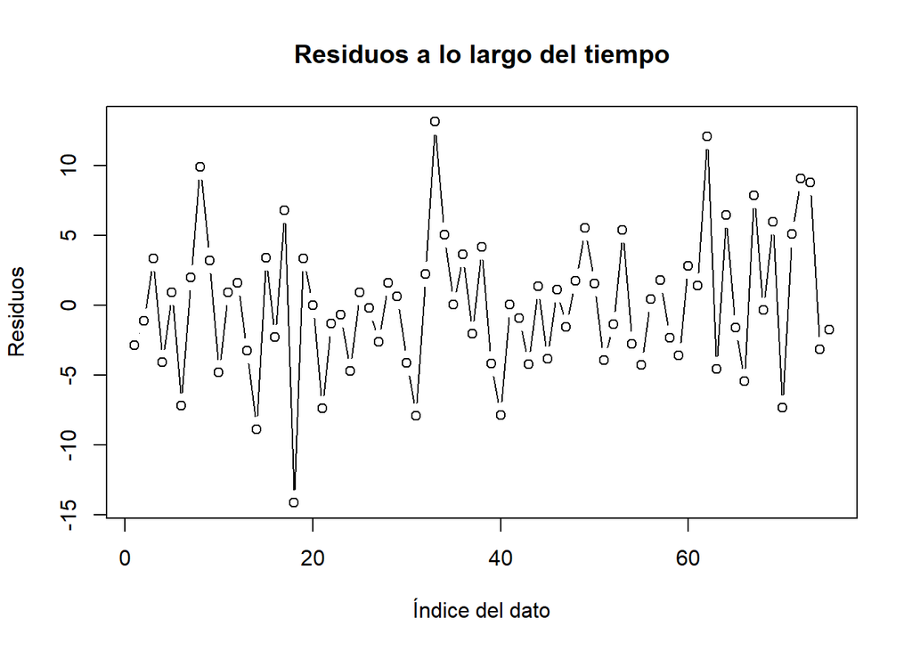

```r
# Grafico
plot(residuals(modelo_cuadratico), type = "b",
     main = "Residuos a lo largo del tiempo",
     ylab = "Residuos", xlab = "Índice del dato")
```

```r
# Test de Durbin-Watson para independencia
dwtest(modelo_cuadratico)
```

```
##
##  Durbin-Watson test
##
## data:  modelo_cuadratico
## DW = 2.1795, p-value = 0.7682
## alternative hypothesis: true autocorrelation is greater than 0
```

```r
# Test Breusch-Pagan para homocedasticidad
bptest(modelo_cuadratico)
```

```
##
##  studentized Breusch-Pagan test
##
## data:  modelo_cuadratico
## BP = 5.1436, df = 6, p-value = 0.5255
```

En el gráfico observamos que los residuos estan disperson sin seguir ningun patrón lo que sugiere que podría cumplirse el supuesto de independencia.

Para analizar el supuesto de independencia se ha aplicado el test de Durbin-Watson en el cual las hipóstesis son:

- Hipótesis nula: las observaciones son independientes por lo que no hay autocorrelación.
- Hipótesis alternativa: hay autocorrelación.

Como se ha obtenido un p-valor>0.05 no se rechaza la hipótesis nula por lo que el supuesto de independencia se cumple.

En cuanto al supuesto de homocedasticidad se ha aplicado el test de Breusch-Pagan en el cual las hipótesis son:

- Hipótesis nula: la varianza de los errores es constante por lo que hay homocedasticidad.
- Hipótesis alternativa: la varianza de los errores no es constante por lo que hay heterocedasticidad.

Como se ha obtenido un p-valor>0.05, no se rechaza la hipótesis nula por lo que el supuesto de homocedasticidad se cumple.

### c. Diagnosis completa del modelo

#### Realizar una evaluación exhaustiva del resto de supuestos del modelo. Utilizar representaciones gráficas y contrastes adecuados. Si detectáis problemas, proponer una corrección mínima razonable (tan solo proponer, sin aplicar).

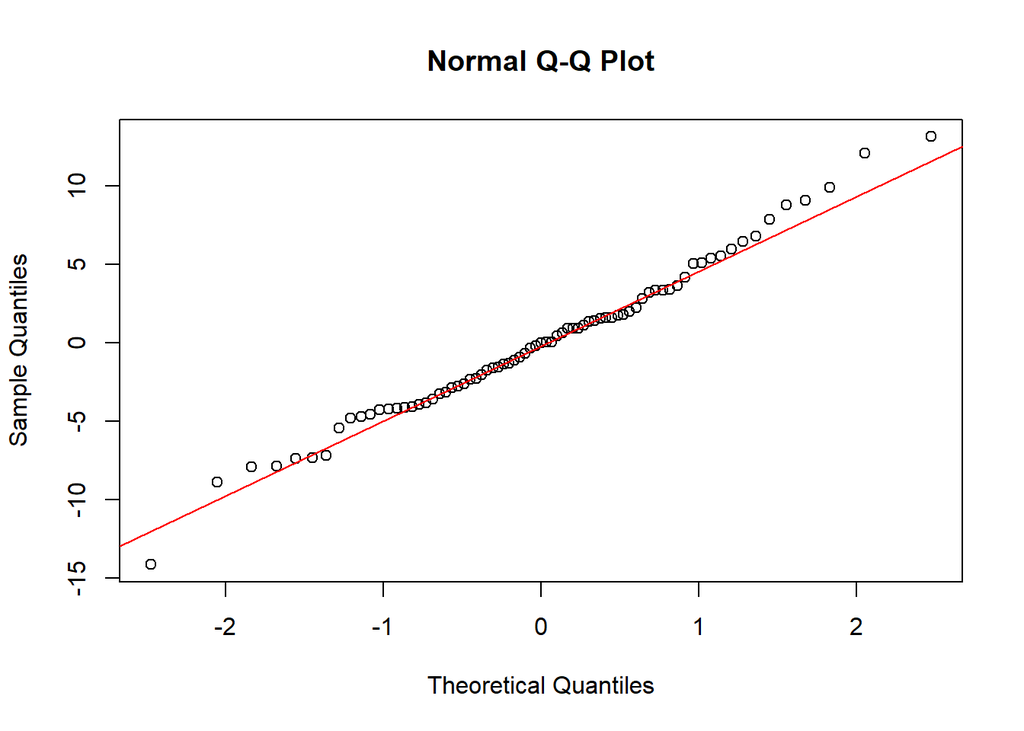

```r
# Supuesto de normalidad
# QQ plot
qqnorm(residuals(modelo_cuadratico))
qqline(residuals(modelo_cuadratico), col="red")
```

```r
# Test de Shapiro-Wilk
shapiro.test(residuals(modelo_cuadratico))
```

```
##
##  Shapiro-Wilk normality test
##
## data:  residuals(modelo_cuadratico)
## W = 0.98822, p-value = 0.7185
```

Se puede observar que el supuesto de normalidad se cumple porque el p-valor es mayor que 0.05 por lo que no se rechazaría la hipótesis nula y los puntos en el QQ plot siguen la línea de referencia.

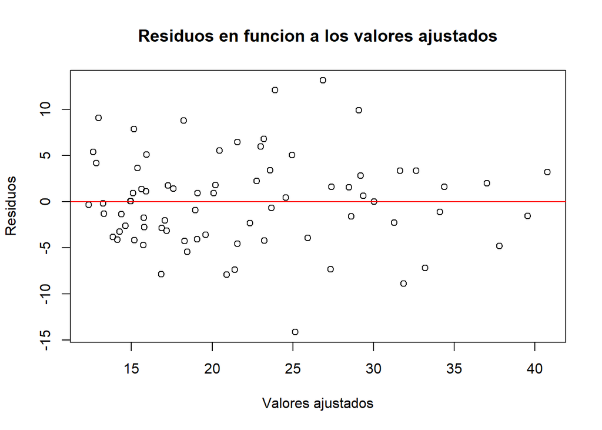

```r
# Supuesto de linealidad
# Gráfico residuos en funcion a los valores ajustados
plot(fitted(modelo_cuadratico), residuals(modelo_cuadratico),
     main = "Residuos en funcion a los valores ajustados",
     xlab = "Valores ajustados", ylab = "Residuos")
abline(h = 0, col = "red")
```

En el gráfico no se observa que haya tendencias claras ni agrupaciones, lo que indica que la relación entre las variables es correcta, por lo que se cumple el supuesto de linealidad.

```r
# Cargamos los paquetes necesarios
library(car)
# Supuesto de multicolinealidad
vif(modelo_cuadratico)
```

```
## there are higher-order terms (interactions) in this model
## consider setting type = 'predictor'; see ?vif
```

```
##       duracion      duracion2       anomalia       temp_max          julio
##      13.023304      11.417494       1.698907       1.976471     818.151456
## temp_max:julio
##     826.963621
```